# Homework 1

Lu Han: lh2659

September 14, 2014

After getting the dataset, the first step is always to make exploratroy data analysis. Graph is the most useful exploratory tool. Here, we use different kinds of graphs to get a brief idea about the questionnaire result.

## Data importing

```r
mques <- read.csv("/Users/HanLu/Documents/Unsorted/QMSS.Vis/labs/questionnaire/responses-2014-09-05.csv", header=T)
colnames(mques)[13] <- "Waitlist" #Define short names.
```

```r
mques <- read.csv("/Users/HanLu/Documents/Unsorted/qmssviz/labs/questionnaire/responses-2014-09-05.csv", header=T)
colnames(mques)[3:13] <- c("Base.ex", "Twitter", "Soft.ex.Rdata", "Soft.ex.Rgraph", "Soft.ex.doc", "Soft.ex.py", "Soft.ex.vc", "Soft.ex.db", "Soft.ex.web", "Soft.ex.java", "Wait") #Define short names.
```

## Single variable plot

In our questionnaire, all the variables are categorical and are read as factors in mques data frame. As for a single factor variable, we can use barplot to look into the distribution of this variable at each level.

For example, if we want to know the distribution of students from different programs, we can plot variable “Program”, and get the following barplot.

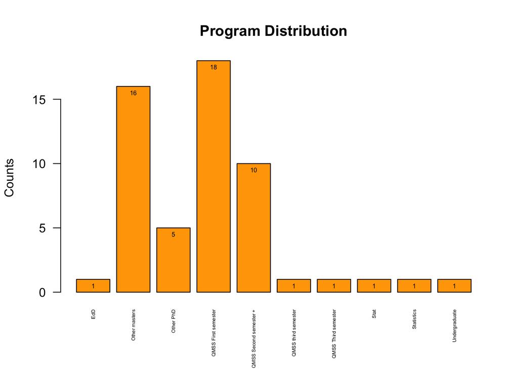

```r
ppro <- plot(mques$Program, main="Program Distribution", ylab="Counts", col="orange", cex.names=0.4, las=2)
counts <- table(mques$Program)
text(y=counts-0.5, x=ppro, lab=as.character(counts), cex=0.5)
```

From the above plot, we can see that most students are first year masters in QMSS, accounting for about one third. And there are also many masters from other program (only 2 students less than QMSS first year masters).